# Praca domowa 4 - Ceteris Paribus

**Autor: Paulina Tomaszewska**

Historical customer attributes at your disposal include:

- Recency: Months since last purchase.
- History_Segment: Categorization of dollars spent in the past year.
- History: Actual dollar value spent in the past year.
- Mens: 1/0 indicator, 1 = customer purchased Mens merchandise in the past year.
- Womens: 1/0 indicator, 1 = customer purchased Womens merchandise in the past year.
- Zip_Code: Classifies zip code as Urban, Suburban, or Rural.
- Newbie: 1/0 indicator, 1 = New customer in the past twelve months.
- Channel: Describes the channels the customer purchased from in the past year.

Another variable describes the e-mail campaign the customer received:

- Segment (Mens E-Mail, Womens E-Mail, No E-Mail)

Finally, we have a series of variables describing activity in the two weeks following delivery of the e-mail campaign:

- Visit: 1/0 indicator, 1 = Customer visited website in the following two weeks.
- Conversion: 1/0 indicator, 1 = Customer purchased merchandise in the following two weeks.
- Spend: Actual dollars spent in the following two weeks.

### Zajmuję się zagadnieniem uplift modelling.

Wytrenowałam kilka klasyfikatorów:

- Gradient Boosting
- Two Model approach using uplift package
- Naive Bayes

W zbiorze danych jest tylko jedna zmienna ciągła - history, która określa ile pieniędzy wydał dany klient w ubiegłym roku (w USD).

Przeanalizowałam dwóch klientów:

- OBSERWACJA "1"

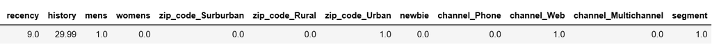

- OBSERWACJA "101"

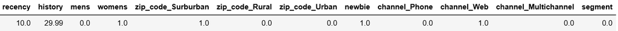

Obaj klienci w terminie 14 dni od otrzymania oferty nie odwiedzili strony internetowej (prawidłowa klasa - 0)

## Ceteris Paribus (obserwacja "1") - ze względu na zmienną history (Gradient Boosting)

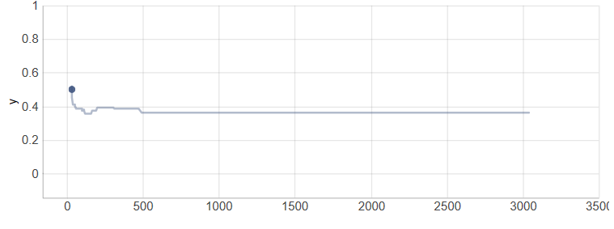

## Ceteris Paribus (obserwacja "101") - ze względu na zmienną history (Gradient Boosting)

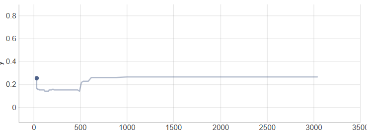

## Wnioski:

### Analizując wykresy Ceteris Paribus można stwierdzić, że nie ma znaczenia ile dany klient wydałby w poprzednim roku na zakupy ponad kwotę 800 USD - prawdopowdobieństwo, że odwiedzi stronę internetową pozostaje takie samo.

## Uśredniony Ceteris Paribus (obserwacja "1" + 100 sąsiadów) - ze względu na zmienną history (Gradient Boosting)

[figure not shown]

## Uśredniony Ceteris Paribus (obserwacja "101" + 100 sąsiadów) - ze względu na zmienną history (Gradient Boosting)

[figure not shown]

### Wnioski: Krzywe Ceteris Paribus są bardzo podobne wśród "obserwacji-sąsiadów"

## Ceteris Paribus(obserwacja "1") - względem zmiennej history (Uplift model)

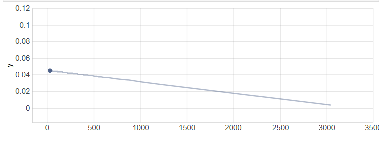

## Ceteris Paribus (obserwacja "101") - względem zmiennej history (Uplift model)

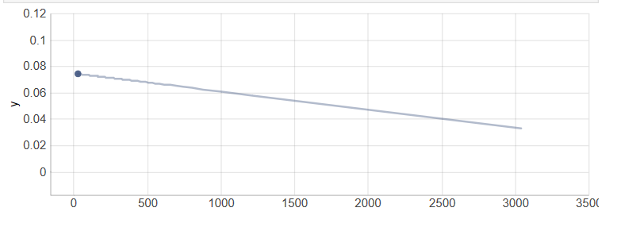

### W przypadku Uplift modelu zauważono, że dla danych klientów im więcej by wydali w poprzenim roku, tym mniejsze jest p-stwo, że odwiedzą stronę internetową w ciągu 2 tygodni (zależność liniowa)

## Ceteris Paribus (obserwacja "1") - względem zmiennej history (Naive Bayes)

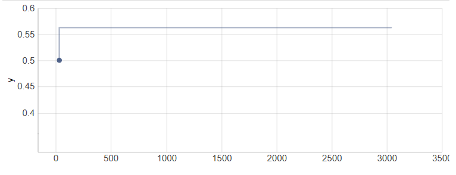

## Ceteris Paribus (obserwacja "101") - względem zmiennej history (Naive Bayes)

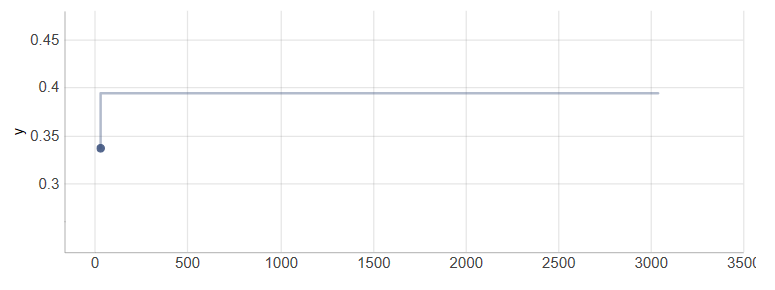

### W przypadku obu obserwacji widoczny jest gwałtowny wzrost prawdopodobieństwa (wraz ze wzrostem zmiennej history), że dana osoba zajrzy na stronę internetową